# Base Model Data Memo Example

Keith Nieforth & James Craig

February 16, 2022

[figure not shown]

# Notes and Conventions

## Notes

- This is an example R Markdown report to demonstrate the workflow for building a “data memo” or report object in parallel with the conduct of a RsNLME analysis.
- We use html output and “tabsets” within the RMarkdown document to show how RsNLME can be used together with R markdown to produce very dense, interactive data summaries that capture a large amount of data in well organized, easily shared delivery mechanism.
- We also show how RsNLME generates code specific to your analysis problem that allows you to get the job done, even if you’re not an R expert!

## Conventions used in this document

- We’ve used blue text boxes to indicate descriptive information
- We’ve used yellow text boxes to indicate results
- Green text boxes provide key messages from the analysis results
- Example: This is a key message statement

```r
# Analysis ID     : Project XYZ Population PK Analysis
# Purpose         : Summarize Base PK model
# Other Info      : Define your own!

library(Certara.RsNLME)
library(Certara.RsNLME.ModelBuilder)
library(Certara.RsNLME.ModelExecutor)
library(Certara.Xpose.NLME)
library(Certara.ModelResults)
library(Certara.VPCResults)
library(tidyvpc)
library(xpose)
library(ggplot2)
library(dplyr)
library(flextable)
library(gtsummary)
library(DescTools)
library(egg)
library(tidyr)

pkdata <- read.csv("pkdata.csv")

#read in base model object that has been fit
```

# Objectives

## Study Design

- 100 healthy and infected male and female subjects were enrolled in this study at 3 centers under inpatient and outpatient settings
- Subjects were administered 100 mg of Drug XYZ intravenously at time=0 and time=24
- Blood samples were obtained at 0, 0.25, 0.5, 1, 2, 4, 6, 8, 12, and 24 hours after the first dose, and 12, and 24 hours after the second dose of Drug XYZ
- Covariates in the dataset include baseline subject weight, age, creatinine clearance, gender, status (healthy or infected) and study center (3 sites), and setting (inpatient or clinic).

## Methods

# Overview of the data

## Summary

- Elimination profile appears to be bi-exponential
- Body weight and gender appear to influence PK

## Categorical covariate summary

```r
pkdata %>%
  filter(TIME == 0) %>%
  mutate(SEX = factor(SEX, labels=c('Male','Female'))) %>%
  select(SEX, STATUS, CENTER, SETTING) %>%
  tbl_summary(by=CENTER) %>%
  modify_header(label = "**Variable**") %>%
  bold_labels() %>%
  modify_spanning_header(all_stat_cols() ~ "**Center**")
```

| **Variable** | **Center** **AB123456**, N = 12<sup>1</sup> | **Center** **AB567765**, N = 50<sup>1</sup> | **Center** **AB765432**, N = 38<sup>1</sup> |
| --- | --- | --- | --- |
| SEX |  |  |  |
| Male | 7 (58%) | 22 (44%) | 17 (45%) |
| Female | 5 (42%) | 28 (56%) | 21 (55%) |
| STATUS |  |  |  |
| HEALTHY | 7 (58%) | 10 (20%) | 13 (34%) |
| INFECTED | 5 (42%) | 40 (80%) | 25 (66%) |
| SETTING |  |  |  |
| Clinic | 0 (0%) | 50 (100%) | 0 (0%) |
| Inpatient | 12 (100%) | 0 (0%) | 38 (100%) |

<sup>*1*</sup> n (%)

## Continuous covariate summary

```r
pkdata %>%
  filter(TIME == 0) %>%
  select(WT, AGE, CRCL, CENTER) %>%
  tbl_summary(by=CENTER,
    statistic = list(all_continuous() ~ "{mean} ({sd}) [{min}-{max}]")) %>%
  modify_header(label = "**Variable**") %>%
  bold_labels() %>%
  modify_spanning_header(all_stat_cols() ~ "**Center**")
```

| **Variable** | **Center** **AB123456**, N = 12<sup>1</sup> | **Center** **AB567765**, N = 50<sup>1</sup> | **Center** **AB765432**, N = 38<sup>1</sup> |
| --- | --- | --- | --- |
| WT | 74 (28) [44-126] | 69 (26) [34-121] | 74 (28) [34-153] |
| AGE | 58 (25) [31-93] | 57 (18) [27-90] | 49 (13) [27-90] |
| CRCL | 91 (10) [78-112] | 88 (11) [66-112] | 91 (11) [71-114] |

<sup>*1*</sup> Mean (SD) [Minimum-Maximum]

## Mean profiles Linear

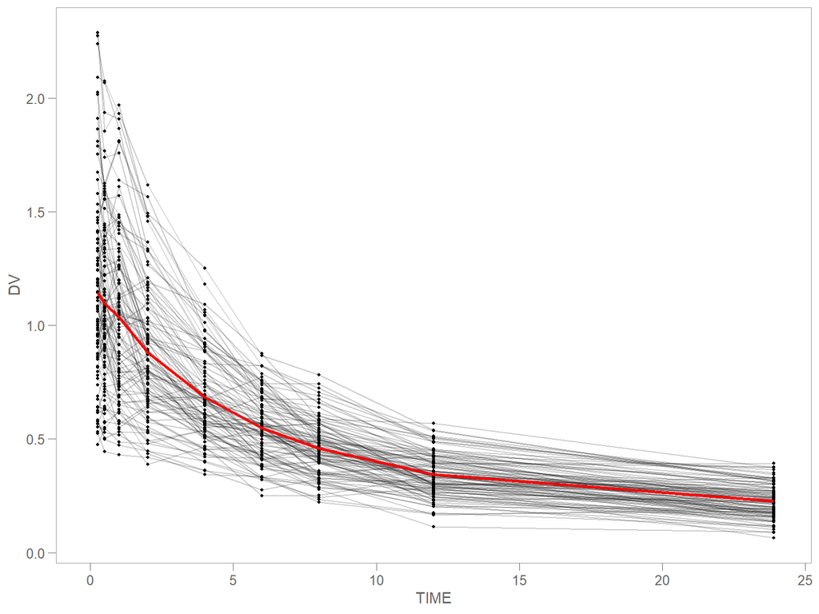

```r
ggplot(subset(pkdata ,AMT==0), aes(x = TIME, y = DV, group = ID)) +
  geom_point(size=.8) +
  geom_line(alpha=.2) +
  scale_x_continuous(limits=c(0,24)) + #limit plot to first dose
  stat_summary(fun.y=mean,geom="line",aes(group=NULL),col='red',size=1) +
  theme_certara()
```

## Mean profiles Log

- bi-exponential disposition

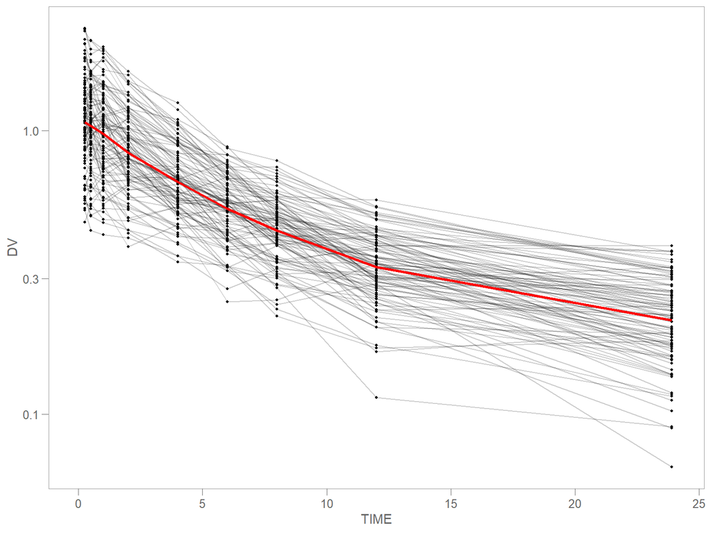

```r
ggplot(subset(pkdata ,AMT==0), aes(x = TIME, y = DV, group = ID)) +
  geom_point(size=.8) +
  geom_line(alpha=.2) +
  scale_x_continuous(limits=c(0,24)) + #limit plot to first dose
  stat_summary(fun.y=mean,geom="line",aes(group=NULL),col='red',size=1) +
  scale_y_log10() +
  theme_certara()
```

## Facet Gender Linear

- Gender influence on PK with higher DV’s in females

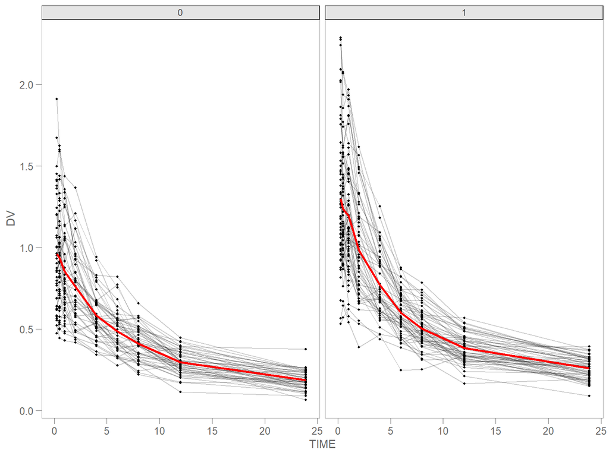

```r
ggplot(subset(pkdata ,AMT==0), aes(x = TIME, y = DV, group = ID)) +
  geom_point(size=.8) +
  geom_line(alpha=.2) +
  scale_x_continuous(limits=c(0,24)) +
  stat_summary(fun.y=mean,geom="line",aes(group=NULL),col='red',size=1) +
  facet_grid(~SEX) +
  theme_certara()
```

## Facet WT Linear

- WT influence on PK with higher DV’s in lower weight subjects

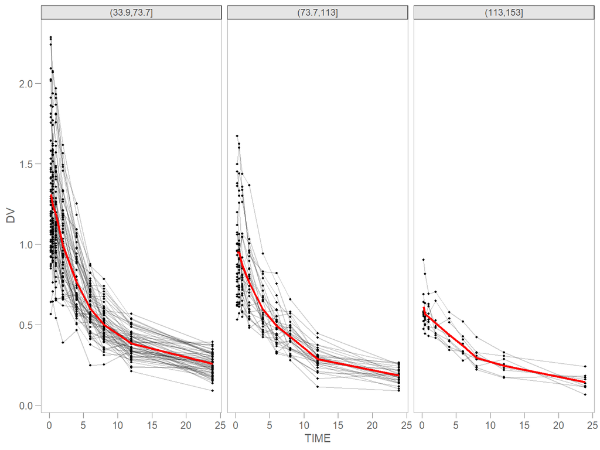

```r
ggplot(subset(pkdata ,AMT==0), aes(x = TIME, y = DV, group = ID)) +
  geom_point(size=.8) +
  geom_line(alpha=.2) +
  scale_x_continuous(limits=c(0,24)) +
  stat_summary(fun.y=mean,geom="line",aes(group=NULL),col='red',size=1) +
  facet_grid(~cut(WT,3)) +
  theme_certara()
```

# Base Model Development

## Summary

- A 2 compartment model with IV bolus input was used to fit the data
- Convergence was achieved with successful estimation of parameter standard errors
- Model fit diagnostics show acceptable fit

## Model Description

- A 2 compartment model with IV bolus input was used to fit the data
- Model parameters central clearance (Cl), central volume (V), inter-compartmental clearance (Cl2), and peripheral compartment volume (V2)
- Between subject variability terms on Cl and V
- Proportional residual error model

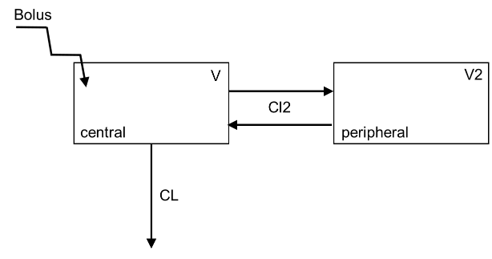

Structural PK Model

```r
ModelName<-"TwoCptIV"

model <- pkmodel(numCompartments = 2,
                  data = pkdata, ID = "ID", Time = "TIME", A1 = "AMT", CObs = "DV",
                  modelName = ModelName)

## Set Initial Estimates and remove Random Effect terms from Cl2 and V2
model <- model %>%
  structuralParameter(paramName = "Cl2", hasRandomEffect = FALSE) %>%
  structuralParameter(paramName = "V2", hasRandomEffect = FALSE) %>%
  fixedEffect(effect = c("tvV", "tvCl", "tvV2", "tvCl2"), value = c(80, 6, 100, 9)) %>%
  randomEffect(effect = c("nV", "nCl"), value = c(0.1, 0.1)) %>%
  residualError(predName = "C", SD = 0.2)

## Add covariates to your model, but don't assign to any parameters yet -- use for base diagnostics

model <- model %>%
  addCovariate(covariate = "WT") %>%
  addCovariate(covariate = "AGE") %>%
  addCovariate(covariate = "CRCL") %>%
  addCovariate(covariate = "SEX", type = "Categorical", levels = c(0, 1),
               labels = c("male", "female"))

## View the updated model
print(model)
```

```
##
##  Model Overview
##  -------------------------------------------
## Is population     :  TRUE
## Model Type        :  PK
##
##  PK
##  -------------------------------------------
## Parameterization  :  Clearance
## Absorption        :  Intravenous
## Num Compartments  :  2
## Dose Tlag?        :  FALSE
## Elimination Comp ?:  FALSE
## Infusion Allowed ?:  FALSE
## Sequential        :  FALSE
## Freeze PK         :  FALSE
##
##  PML
##  -------------------------------------------
## test(){
##     cfMicro(A1,Cl/V, Cl2/V, Cl2/V2)
##     dosepoint(A1)
##     C = A1 / V
##     error(CEps=0.2)
##     observe(CObs=C * ( 1 + CEps))
##     stparm(V = tvV * exp(nV))
##     stparm(Cl = tvCl * exp(nCl))
##     stparm(V2 = tvV2)
##     stparm(Cl2 = tvCl2)
##     fcovariate(WT)
##     fcovariate(AGE)
##     fcovariate(CRCL)
##     fcovariate(SEX())
##     fixef( tvV = c(,80,))
##     fixef( tvCl = c(,6,))
##     fixef( tvV2 = c(,100,))
##     fixef( tvCl2 = c(,9,))
##     ranef(diag(nV,nCl) = c(0.1,0.1))
## }
##
```

[output cut: 8 more lines]

```
## Epsilon Type     :  Multiplicative
## Epsilon frozen   :  FALSE
## is BQL           :  FALSE
##  -------------------------------------------
##  Column Mappings
##  -------------------------------------------
## Model Variable Name : Data Column name
## id                  : ID
## time                : TIME
## A1                  : AMT
## WT                  : WT
## AGE                 : AGE
## CRCL                : CRCL
## SEX                 : SEX( male=0 female=1 )
## CObs                : DV
```

```r
## Fit the model
TwoCptIVfit <- fitmodel(model)
```

```
##
## Host argument is not given. Using MPI host with 4 cores
```

```
##
## NLME Job
```

```
## sharedDirectory is not given in the host class instance.
```

```
## Valid NLME_ROOT_DIRECTORY is not given, using current working directory:
## C:/Users/jcraig/Documents/GitHub/RsNLME-Rmd-Report-Example
```

```
##
##  Compiling 1 of 1 NLME models
## The model compiled
##
##  Iteration     -2LL     tvV    tvCl    tvV2   tvCl2 nSubj nObs
##          1 -2015.93 88.8431 5.10690 91.1316 8.29081   100 1100
##          2 -2028.20 89.4815 5.03963 90.1857 7.64443   100 1100
##          3 -2029.82 90.4726 5.05008 91.3106 7.56922   100 1100
##          4 -2031.88 91.9194 4.99275 93.6416 7.54101   100 1100
##          5 -2032.65 91.9300 4.94629 95.5530 7.57691   100 1100
##          6 -2032.89 91.4079 4.90884 97.1109 7.58953   100 1100
##          7 -2032.94 90.9945 4.88762 97.5599 7.59734   100 1100
##          8 -2032.98 90.6212 4.87443 97.9503 7.59627   100 1100
##          9 -2033.01 90.5810 4.86685 98.3785 7.59720   100 1100
##         10 -2033.04 90.7660 4.85162 99.0035 7.59301   100 1100
##         11 -2033.05 90.9292 4.85124 99.1087 7.59336   100 1100
##         12 -2033.05 91.0471 4.84952 99.2146 7.59347   100 1100
##         13 -2033.05 90.9881 4.85042 99.2337 7.59490   100 1100
##
## Trying to generate job results...
##
##  Generating Overall.csv
##  Generating StatusWindow.txt
##  Generating EtaEta.csv
##  Generating EtaCov.csv
##  Generating StrCovariate.csv
##  Generating ConvergenceData.csv
##  Generating initest.csv
##  Generating doses.csv
##  Generating omega.csv
##  Generating omega_stderr.csv
##  Generating thetas.csv
##  Generating Eta.csv and EtaStacked.csv
##  Generating Residuals.csv
##  Generating posthoc.csv and table0n.csv
##
## Finished summarizing results. Transferring data and loading the results...
## Done generating job results.
```

## GOF Plots

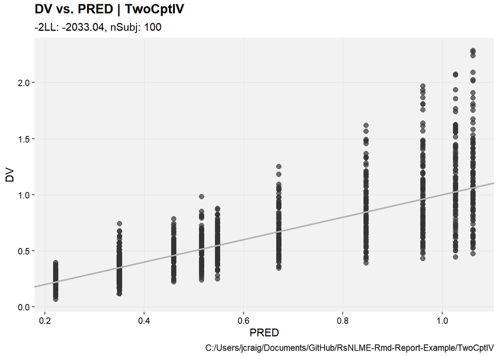

```r
xp <- xposeNlme(dir = model@modelInfo@workingDir, modelName = ModelName)

##  DV vs PRED/IPRED, Residuals, -- Many more diagnostics available in xpose package
dv_vs_pred(xp, type = "p", subtitle = "-2LL: @ofv, nSubj: @nind")
```

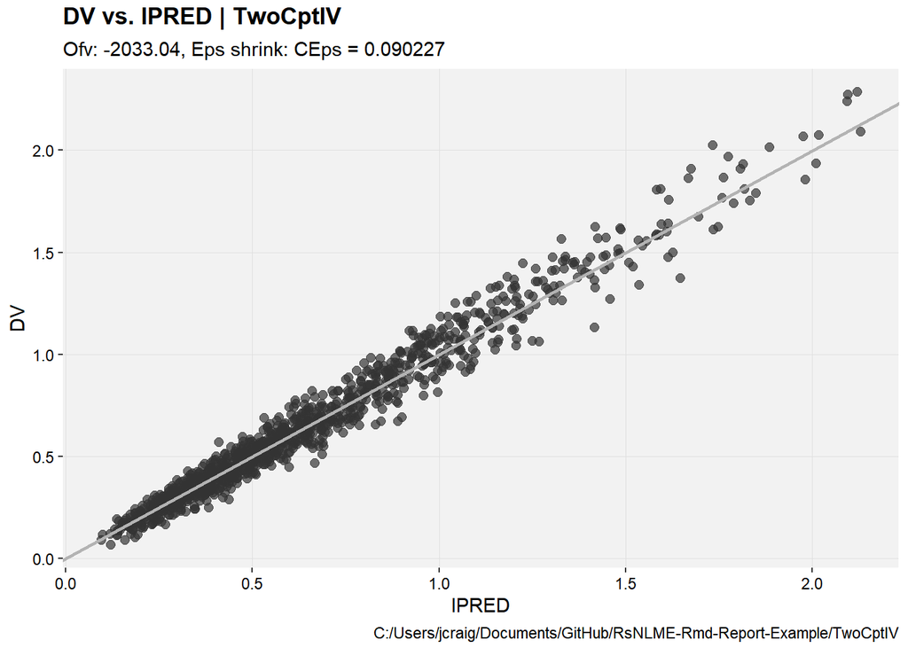

```r
dv_vs_ipred(xp, type = "p")
```

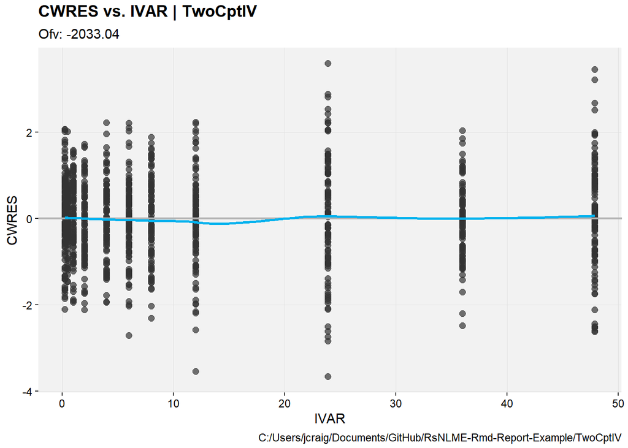

```r
res_vs_idv(xp, type = "ps")
```

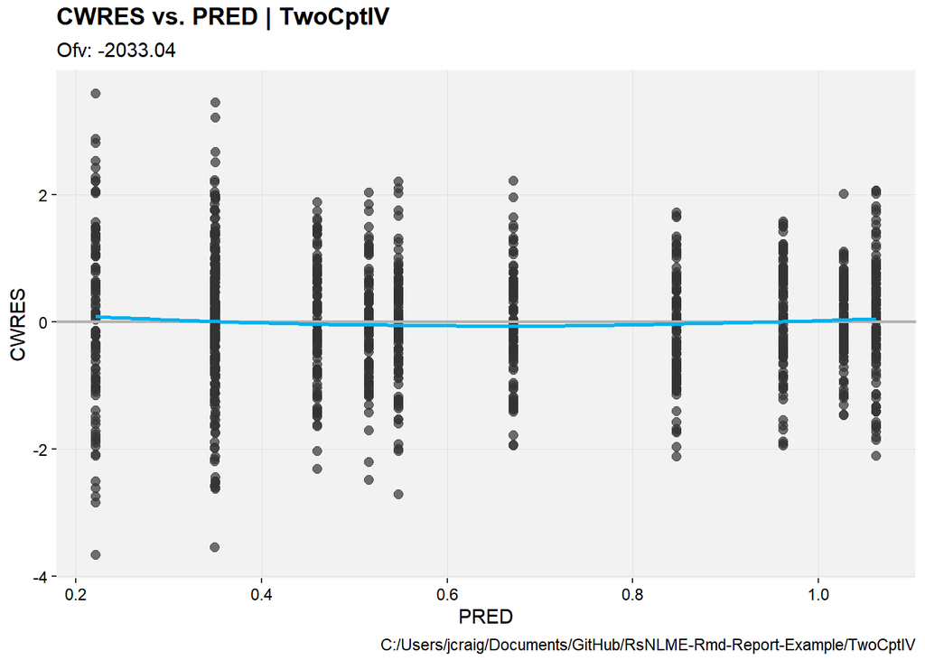

```r
res_vs_pred(xp, type = "ps")
```

## Parameter Estimates

```r
table <- xp %>%
  get_overallNlme() %>%
  mutate(RetCode = as.integer(RetCode), nObs = as.integer(nObs), nSub = as.integer(nSub), nParm = as.integer(nParm)) %>%
  flextable(col_keys = c("RetCode", "Condition", "logLik", "-2LL", "AIC", "BIC", "nParm", "nObs", "nSub")) %>%
  set_header_labels(values = list(RetCode = "RetCode", Condition = "Condition", logLik = "LL", `-2LL` = "-2LL", AIC = "AIC", BIC = "BIC", nParm = "nParm", nObs = "nObs", nSub = "nSub")) %>%
  set_caption(caption = "Table Overall") %>%
  add_footer_row(values = "Source: script.R", colwidths = 9L) %>%
  colformat_double(digits = 1L) %>%
  align(align = "left", part = "all") %>%
  set_table_properties(layout = "autofit") %>%
  autofit() %>%
  fontsize(size = 10, part = "all") %>%
  font(fontname = "Times New Roman", part = "all") %>%
  bold(part = "header")
table
```

Table Overall

| RetCode | Condition | LL | -2LL | AIC | BIC | nParm | nObs | nSub |
| --- | --- | --- | --- | --- | --- | --- | --- | --- |
| 1 | 87.2 | 1,016.5 | -2,033.0 | -2,019.0 | -1,984.0 | 7 | 1,100 | 100 |

Source: script.R

Table Theta

| Name | Label | Value | SE | RSE% | Fixed | 2.5% CI | 97.5% CI |
| --- | --- | --- | --- | --- | --- | --- | --- |
| THETA(1) | tvV | 90.99 | 3.28 | 3.61 | FALSE | 84.55 | 97.43 |
| THETA(2) | tvCl | 4.85 | 0.29 | 6.08 | FALSE | 4.27 | 5.43 |
| THETA(3) | tvV2 | 99.23 | 9.81 | 9.88 | FALSE | 79.99 | 118.47 |
| THETA(4) | tvCl2 | 7.59 | 0.22 | 2.92 | FALSE | 7.16 | 8.03 |

Source: script.R

Table Omega

| Name | Label | Value | SE | RSE% | Fixed | Diagonal | 2.5% CI | 97.5% CI | Shrinkage% |
| --- | --- | --- | --- | --- | --- | --- | --- | --- | --- |
| OMEGA(1,1) | nV | 0.134 | 0.017 | 12.506 | FALSE | TRUE | 0.101 | 0.167 | 1.790 |
| OMEGA(2,2) | nCl | 0.143 | 0.024 | 16.635 | FALSE | TRUE | 0.096 | 0.190 | 2.443 |

Source: script.R

Table Sigma

| Name | Label | Value | SE | RSE% | Fixed | 2.5% CI | 97.5% CI | Shrinkage% |
| --- | --- | --- | --- | --- | --- | --- | --- | --- |
| SIGMA(1,1) | CEps | 0.127 | 0.004 | 2.819 | FALSE | 0.120 | 0.134 | 9.023 |

Source: script.R

## Visual Predictive Check

```r
vpcmod <- copyModel(model, acceptAllEffects = TRUE, modelName = "vpc")

## Set up VPC arguments to have PRED outputted to simulation output dataset "predout.csv"
vpcSetup <- NlmeVpcParams(numReplicates=100)

## run the vpc using the vpcmodel function
vpcfit <- vpcmodel(model = vpcmod, vpcParams = vpcSetup)
```

```
##
## Host argument is not given.
## Using localhost without parallelization.
```

```
##
## NLME Job
```

```
## sharedDirectory is not given in the host class instance.
```

```
## Valid NLME_ROOT_DIRECTORY is not given, using current working directory:
## C:/Users/jcraig/Documents/GitHub/RsNLME-Rmd-Report-Example
```

```
##
##  Compiling 1 of 1 NLME models
## The model compiled
##
## Trying to generate job results...
##
##
## Finished summarizing results. Transferring data and loading the results...
## Done generating job results.
##
## VPC/Simulation results are ready in  C:/Users/jcraig/Documents/GitHub/RsNLME-Rmd-Report-Example/vpc
## Loading the results
## Loading  predcheck_bql.csv
## Loading  predcheck0.csv
## Loading  predcheck0_cat.csv
## Loading  predcheck1.csv
## Loading  predcheck1_cat.csv
## Loading  predcheck2.csv
## Loading  predcheck2_cat.csv
## Loading  predout.csv
```

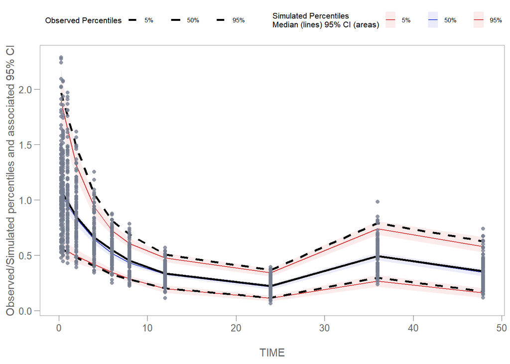

```r
## VPC simulation input dataset (obs data)
ObsData <- vpcfit$predcheck0

## VPC simulation output dataset
SimData <- vpcfit$predout


vpc <- observed(ObsData, x = IVAR, y = DV) %>%
  simulated(SimData, y = DV) %>%
  binless(optimize = TRUE, interval = c(0L, 7L)) %>%
  vpcstats(qpred = c(0.05, 0.5, 0.95), conf.level = 0.95, quantile.type = 6)

vpcPlot <- ggplot(vpc$stats, aes(x = x)) +
  geom_ribbon(aes(ymin = lo, ymax = hi, fill = qname, col = qname, group = qname), alpha = 0.1, col = NA) +
  geom_line(aes(y = md, col = qname, group = qname)) +
  geom_line(aes(y = y, linetype = qname), size = 1) +
  geom_point(data = vpc$obs[!(blq | alq)], aes(x = x, y = y), color = "#757D8F", size = 1.5, shape = 16, alpha = 0.8, show.legend = FALSE) +
  scale_colour_manual(name = "Simulated Percentiles\nMedian (lines) 95% CI (areas)", breaks = c("q0.05", "q0.5", "q0.95"), values = c("#D63636", "#3648D6", "#D63636"), labels = c("5%", "50%", "95%")) +
  scale_fill_manual(name = "Simulated Percentiles\nMedian (lines) 95% CI (areas)", breaks = c("q0.05", "q0.5", "q0.95"), values = c("#D63636", "#3648D6", "#D63636"), labels = c("5%", "50%", "95%")) +
  scale_linetype_manual(name = "Observed Percentiles", breaks = c("q0.05", "q0.5", "q0.95"), values = c("dashed", "solid", "dashed"), labels = c("5%", "50%", "95%")) +
  guides(fill = guide_legend(order = 2), colour = guide_legend(order = 2), linetype = guide_legend(order = 1)) +
  ylab(sprintf("Observed/Simulated percentiles and associated %s%% CI", 100 * vpc$conf.level)) +
  xlab("\nTIME") +
  theme_certara() +
  theme(legend.position = "top",
       legend.title=element_text(size=8),
       legend.text=element_text(size=6),
       legend.key.width = unit(0.4, 'cm'))

vpcPlot
```

# Target Attainment Simulation

## Summary

For 100 mg q24h * 7 dose regimen, Cmax and AUC24 on day 7:

## Plots

```r
pkdatasim <- pkdata %>%    #make a copy of original dataset
  filter(TIME==0) %>%    #keep only rows where time=0
  mutate(ADDL=6,II=24)   #add ADDL (additional doses) and II (interdose interval) variables

#Make a copy of our final model
modelTAsim <- copyModel(model, acceptAllEffects = TRUE, modelName = "modelTAsim")

#replace dataset with pkdatasim using the dataMapping function
modelTAsim <- modelTAsim %>%
  dataMapping(pkdatasim)

#Map AMT and DV to A1 and CObs
modelTAsim <- modelTAsim %>%
  colMapping(c(A1="AMT", CObs="DV"))

#Use addADDL to map multiple dose variables
modelTAsim <- modelTAsim %>%
  addADDL(ADDL="ADDL", II="II")

#Define table we want as output from the simulation
SimTable <- NlmeSimTableDef(name="SimTable.csv",
                            timesList = seq(144,168,1),
                            variablesList = c("C", "CObs","WT","SEX"))
## Simulation setup
SimSetup <- NlmeSimulationParams(numReplicates = 50,
                                 seed = 1234,
                                 simulationTables = c(SimTable))

## Run the model
modelTAsimfit <- simmodel(modelTAsim, SimSetup)
```

```
##
## NLME Job
##
##  Compiling 1 of 1 NLME models
## The model compiled
##
## Trying to generate job results...
##
##
## Finished summarizing results. Transferring data and loading the results...
## Done generating job results.
##
## VPC/Simulation results are ready in  C:/Users/jcraig/Documents/GitHub/RsNLME-Rmd-Report-Example/modelTAsim
## Loading the results
## Loading  SimTable.csv
## Loading  predout.csv
```

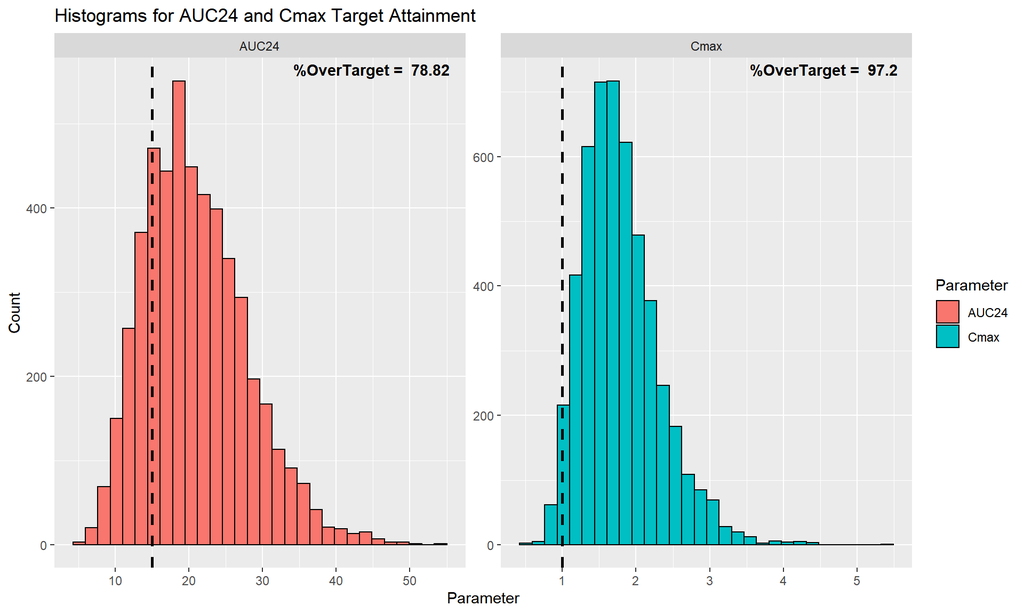

```r
## Plot simulation results
## Simulated drug concentration at the central compartment
## Read in the simulation output dataset specified in the call to NlmeSimTableDef

## can read the file in from the simulation directory
## SimTableout<-read.csv("<path>/SimTable.csv")

## Or, can extract it from the simulation fit object
SimTableout <- modelTAsimfit$SimTable %>%
  rename("Replicate"="# repl")  #rename repl column to Replicate

## Calculate Cmax and AUC (AUC function from DescTools library)

pkparms <- SimTableout %>%
  group_by(Replicate, id5) %>%
  mutate(Cmax = max(CObs),
         AUC24 = AUC(time,CObs)) %>%
  distinct(Replicate, id5, .keep_all = T) %>%
  select(Replicate, id5, SEX, WT, Cmax, AUC24)

#Make Some Plots

targetCmax <- 1    #enter the threshold you'd like to use
targetAUC24 <- 15    #enter the threshold you'd like to use

overtargetAUC24<-length(which(pkparms$AUC24 > targetAUC24)) / length(pkparms$AUC24) * 100
overtargetCmax<-length(which(pkparms$Cmax > targetCmax)) / length(pkparms$Cmax) * 100

TAplotdat <- pkparms %>% pivot_longer(cols=c(Cmax,AUC24),names_to="Parameter") %>%
mutate(target = ifelse(Parameter=="AUC24",targetAUC24,targetCmax))

p1<-ggplot(TAplotdat,aes(x = value, fill=Parameter)) +
  labs(x="Parameter", y="Count",title="Histograms for AUC24 and Cmax Target Attainment") +
  geom_histogram(col="black") +                 #create the histogram
  geom_vline(aes(xintercept = target), lty=2, lwd=1) + #add a vertical line with our target
  facet_wrap(vars(Parameter),scales="free")         #wrap by Parameter (AUC and Cmax)


#we can use tag_facet from the egg package to add some custom text to the plots

p1<-tag_facet(p1, x=Inf,y=Inf,
          open = "",
          close = "",
          tag_pool=c(paste("%OverTarget = ",overtargetAUC24),   #this uses the % values we created earlier
                     paste("%OverTarget = ",overtargetCmax)),
          hjust = 1.1,
          vjust = 1.5) +
  theme(strip.text = element_text(),strip.background = element_rect())

p1
```

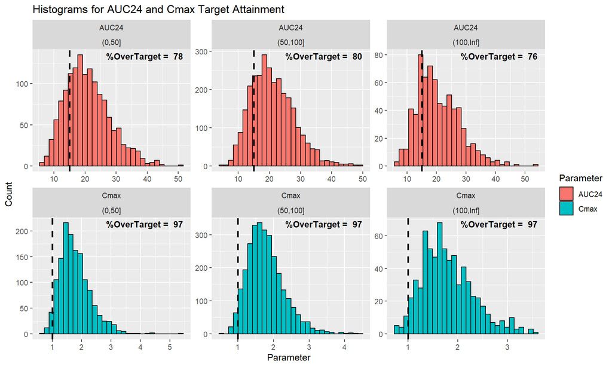

```r
## Facet by WT Categories <50kg, 50-100kg, >100kg
TAplotdat <- TAplotdat %>%
  mutate(WTcut = cut(WT,breaks=c(0,50,100,Inf)))

#calculate attainment by facets

TAsummary <- pkparms %>%
  group_by(cut(WT,breaks=c(0,50,100,Inf))) %>%
  summarize(pctovrCmax = round(length(which(Cmax > targetCmax)) / length(Cmax) * 100,0),
            pctovrAUC24 = round(length(which(AUC24 > targetAUC24)) / length(AUC24) * 100,0))

#plot
p2<-ggplot(TAplotdat,aes(x = value, fill=Parameter)) +
  labs(x="Parameter", y="Count",title="Histograms for AUC24 and Cmax Target Attainment") +
  geom_histogram(col="black") +
  geom_vline(aes(xintercept = target), lty=2, lwd=1) +
  facet_wrap(Parameter ~ WTcut, scales="free")

#we can use tag_facet from the egg package to add some custom text to the plots

p2<-tag_facet(p2, x=Inf, y=Inf, open = "", close = "",
          tag_pool=c(paste("%OverTarget = ",TAsummary$pctovrAUC24[1]),
                     paste("%OverTarget = ",TAsummary$pctovrAUC24[2]),
                     paste("%OverTarget = ",TAsummary$pctovrAUC24[3]),
                     paste("%OverTarget = ",TAsummary$pctovrCmax[1]),
                     paste("%OverTarget = ",TAsummary$pctovrCmax[2]),
                     paste("%OverTarget = ",TAsummary$pctovrCmax[3])),
          hjust = 1.1,
          vjust = 1.5,
          size=3.5) +
theme(strip.text = element_text(),strip.background = element_rect())

p2
```